# Intro to Tidy Data in R (tidyr)

2017-02-20

## “Tidy datasets are all alike but every messy dataset is messy in its own way.” – Hadley Wickham

## Outline

We are interested:

1. Wide vs. Long data
2. What is Tidy Data?
3. Vectorized operations
4. Separate vs. Unite

## Long vs. Wide Data Formats

### Human vs. computer readable

Easiest to understand with an example.

Wide Format

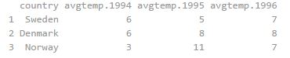

Quite easy for humans to read. We are used to this format from having read tables. (Especially MS-Excel)

Note: One entity (country) has multiple values per row.

Long Format

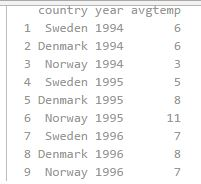

A long format is not easy for humans. But it turns out to be an excellent format for performing analysis and for plotting.

Note: Only one numerical value per row (country)

## Tidy Data

Tidy data is the data that resulting from the process called `data tidying.`, The Tidy data sets have structure and working with them are easy, they’re easy to manipulate, model and visualize. Tidy data sets main concept is to arrange data in a way that each variable is a column and each observation is a row.

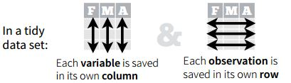

## Vectorized Operations

Vectorized operations is fundamental to how R operates. Very useful once we understand how it works.

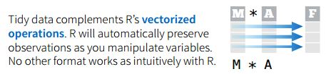

## Long vs. Wide Data Formats

### Converting from one to the other

We frequently end up doing this. This is also called `pivoting.`

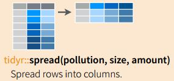

R command to use: `spread()`

Part of tidyr package

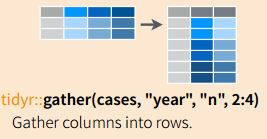

R command to use: `gather()`

This is sometimes referred to as 'melting' a data frame

## Let's Practice with some data

Let's read the Crude Oil Data

```r
library(dplyr)
```

```r
df <- read.csv(file='data/CrudeOilProduction.csv', stringsAsFactors = F)
us_oil <- df %>% filter(Country=="USA", Time>2010) %>%
  select(-Indicator, -Subject, -Units, -Flag.Codes)

head(us_oil)
```

```
##   Country Frequency Time Quantity
## 1     USA         A 2011 288542.0
## 2     USA         A 2012 330942.3
## 3     USA         A 2013 379905.9
## 4     USA         A 2014 443927.4
## 5     USA         A 2015 480639.5
```

How do we convert this to a 'wide' format?

- `key` is the column to spread into multiple colums
- `value` is the column with *values* to spread into multiple columns

```r
library(tidyr)
wide <- us_oil %>% spread(key=Time, value=Quantity)
head(wide)
```

```
##   Country Frequency   2011     2012     2013     2014     2015
## 1     USA         A 288542 330942.3 379905.9 443927.4 480639.5
```

## Going from Wide to Long format

`mtcars` (built-in dataset) is wide.

```r
mtcars$car <- rownames(mtcars) #create a new column called car
rownames(mtcars) <- NULL #get rid of rownames. we don't want that since we have the `car` column
head(mtcars,4)
```

```
##    mpg cyl disp  hp drat    wt  qsec vs am gear carb            car
## 1 21.0   6  160 110 3.90 2.620 16.46  0  1    4    4      Mazda RX4
## 2 21.0   6  160 110 3.90 2.875 17.02  0  1    4    4  Mazda RX4 Wag
## 3 22.8   4  108  93 3.85 2.320 18.61  1  1    4    1     Datsun 710
## 4 21.4   6  258 110 3.08 3.215 19.44  1  0    3    1 Hornet 4 Drive
```

```r
dim(mtcars)
```

```
## [1] 32 12
```

Question: If we made this into a LONG dataframe, how many rows would that have?

## Let's melt the data frame

```r
long_cars <- mtcars %>% gather(attribute, value, -car)
head(long_cars)
```

```
##                 car attribute value
## 1         Mazda RX4       mpg  21.0
## 2     Mazda RX4 Wag       mpg  21.0
## 3        Datsun 710       mpg  22.8
## 4    Hornet 4 Drive       mpg  21.4
## 5 Hornet Sportabout       mpg  18.7
## 6           Valiant       mpg  18.1
```

So who got it right?!

```r
dim(long_cars)
```

```
## [1] 352   3
```

## Using the `separate` command

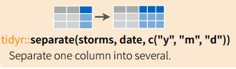

## Using the `unite` command